# Shaping a Happier World: Insights from the 2017 World Happiness Report

Rohan Arora

5/1/2023

# 1 The World Happiness Report 2017

## 1.1 Background

The World Happiness Report is a publication that ranks countries based on their happiness levels. The rankings are determined by the responses to the Gallup World Poll, an annual survey of individuals in over 150 countries. The United Nations Sustainable Development Solutions Network publishes the report. The report also includes an analysis of the data, focusing on how happiness is affected by various factors, such as economic and social development, health, and good governance. These individual responses are turned into a score on a scale of 1 through 10. The measured variables include real GDP per capita, social support, life expectancy, freedom to choose, generosity, and perceptions of corruption. We looked at the 2017 report as it contained the most data.

## 1.2 Social Good

The World Happiness Report can help policymakers and others interested in promoting well-being in their countries. By providing a ranking of countries based on their happiness levels, the report can be used to identify areas where improvements can be made. For example, suppose a country has a low ranking in the report. In that case, policymakers can use the data and analysis provided to determine what factors contribute to the low ranking and take action to address those factors. Additionally, the report can be used to raise awareness about the importance of promoting well-being and happiness in society. By highlighting the role that factors such as economic and social development, health, and good governance play in determining happiness, the report can promote a broader understanding of the factors that contribute to well-being and inspire action to improve those factors.

## 1.3 SMART Question

Based on data collected in the 2017 World Happiness Report, which features are most impactful in determining a happiness score, and how much do these correlations differ across regions?

## 1.4 Cleaning

```r
#add dataset called 2017.csv in the zipfile
X2017 = read.csv("2017.csv")
```

### 1.4.1 Original Dataset

```r
str(X2017)
```

```
## 'data.frame':    155 obs. of  12 variables:
##  $ Country                      : chr  "Norway" "Denmark" "Iceland" "Switzerland" ...
##  $ Happiness.Rank               : int  1 2 3 4 5 6 7 8 9 10 ...
##  $ Happiness.Score              : num  7.54 7.52 7.5 7.49 7.47 ...
##  $ Whisker.high                 : num  7.59 7.58 7.62 7.56 7.53 ...
##  $ Whisker.low                  : num  7.48 7.46 7.39 7.43 7.41 ...
##  $ Economy..GDP.per.Capita.     : num  1.62 1.48 1.48 1.56 1.44 ...
##  $ Family                       : num  1.53 1.55 1.61 1.52 1.54 ...
##  $ Health..Life.Expectancy.     : num  0.797 0.793 0.834 0.858 0.809 ...
##  $ Freedom                      : num  0.635 0.626 0.627 0.62 0.618 ...
##  $ Generosity                   : num  0.362 0.355 0.476 0.291 0.245 ...
##  $ Trust..Government.Corruption.: num  0.316 0.401 0.154 0.367 0.383 ...
##  $ Dystopia.Residual            : num  2.28 2.31 2.32 2.28 2.43 ...
```

### 1.4.2 The Cleaned Dataset

```r
#renaming variables
colnames(X2017)[0:11]=c("Country", "Happiness.Rank","Happiness.Score","Whisker.high", "Whisker.low", "Economy", "Life.Expectancy", "Freedom", "Generosity", "Trust in Gov","Dystopian.Residual")
newhappiness<-X2017
#creating regions
newhappiness$Regionnc = countrycode(sourcevar = newhappiness$Country, origin = "country.name",destination = "region")
#getting rid of whisker variables
newhappiness$Whisker.high=NULL
newhappiness$Whisker.low=NULL
newhappiness$Dystopia.Residual=NULL
newhappiness$Region <- as.factor(newhappiness$Regionnc)
newhappiness$Regionnc=NULL
```

```r
str(newhappiness)
```

```
## 'data.frame':    155 obs. of  10 variables:
##  $ Country           : chr  "Norway" "Denmark" "Iceland" "Switzerland" ...
##  $ Happiness.Rank    : int  1 2 3 4 5 6 7 8 9 10 ...
##  $ Happiness.Score   : num  7.54 7.52 7.5 7.49 7.47 ...
##  $ Economy           : num  1.62 1.48 1.48 1.56 1.44 ...
##  $ Life.Expectancy   : num  1.53 1.55 1.61 1.52 1.54 ...
##  $ Freedom           : num  0.797 0.793 0.834 0.858 0.809 ...
##  $ Generosity        : num  0.635 0.626 0.627 0.62 0.618 ...
##  $ Trust in Gov      : num  0.362 0.355 0.476 0.291 0.245 ...
##  $ Dystopian.Residual: num  0.316 0.401 0.154 0.367 0.383 ...
##  $ Region            : Factor w/ 7 levels "East Asia & Pacific",..: 2 2 2 2 2 2 5 1 2 1 ...
```

```r
summary(newhappiness[1:8], title = "Statistics Summary of Variables")
```

```
##    Country          Happiness.Rank  Happiness.Score    Economy
##  Length:155         Min.   :  1.0   Min.   :2.693   Min.   :0.0000
##  Class :character   1st Qu.: 39.5   1st Qu.:4.505   1st Qu.:0.6634
##  Mode  :character   Median : 78.0   Median :5.279   Median :1.0646
##                     Mean   : 78.0   Mean   :5.354   Mean   :0.9847
##                     3rd Qu.:116.5   3rd Qu.:6.101   3rd Qu.:1.3180
##                     Max.   :155.0   Max.   :7.537   Max.   :1.8708
##  Life.Expectancy    Freedom         Generosity      Trust in Gov
##  Min.   :0.000   Min.   :0.0000   Min.   :0.0000   Min.   :0.0000
##  1st Qu.:1.043   1st Qu.:0.3699   1st Qu.:0.3037   1st Qu.:0.1541
##  Median :1.254   Median :0.6060   Median :0.4375   Median :0.2315
##  Mean   :1.189   Mean   :0.5513   Mean   :0.4088   Mean   :0.2469
##  3rd Qu.:1.414   3rd Qu.:0.7230   3rd Qu.:0.5166   3rd Qu.:0.3238
##  Max.   :1.611   Max.   :0.9495   Max.   :0.6582   Max.   :0.8381
```

I have now cleaned the dataset to be usable for my analysis by removing unnecessary variables and categorizing the countries into regions. So we can start looking at the dataset and begin data analysis of the World Happiness Report 2017.

# 2 Data Analysis

## 2.1 Exploratory Data Analysis

When I cleaned the dataset, my initial thought was to see what variables correlate with `Happiness.Score`. So, I created a correlation matrix of those variables and `Happiness.Score`.

### 2.1.1 Correlation Matrix for Entire Dataset

```r
#Correlation Matrix for 2017 World Happiness Report
corPearson = cor(newhappiness[3:8])
```

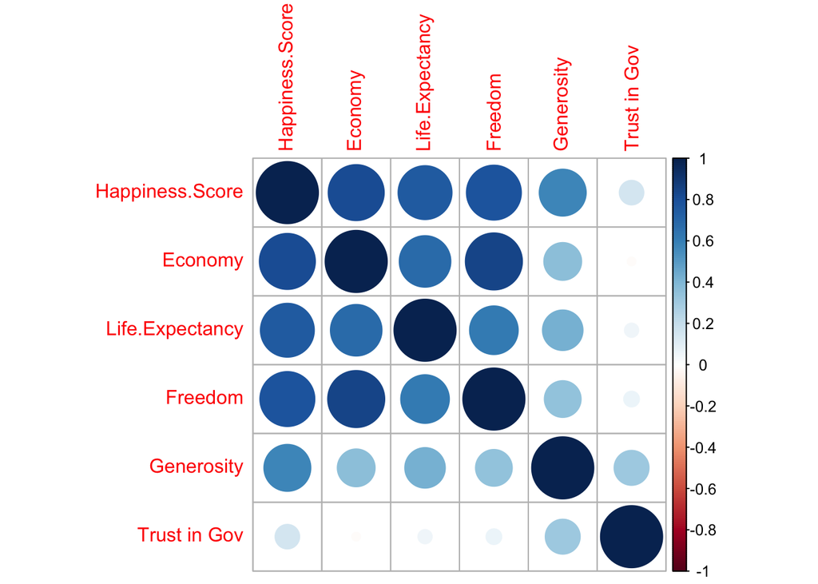

```r
corrplot(corPearson)
```

This correlation plot highlights that the three most correlated variables with `Happiness.Score` are the `Economy`, `Life.Expectancy`, and `Freedom` scores. `Economy` is the highest correlated, followed by `Freedom` and `Life.Expectancy`. While this correlation matrix was made for all pieces of data, I wanted to look deeper into the data to see if this message would change depending on the specific region. Countries may have different sources of happiness for a variety of reasons. One reason is that countries may have different cultural values and beliefs, affecting what people consider essential for their happiness. For example, in some cultures, family and community connections may be more important for happiness than individual achievement, while personal success and achievement may be more valued in other cultures. I decided to see if specific regions had different correlations than the entire dataset.

Before I began to study the individual correlations of specific regions, I wanted to look at the difference in `Happiness.Score` per region. This would give us a bigger picture of regions’ `Happiness.Score` distribution. Keeping this in the back of my mind, I could look at the effect of different areas on the correlation of specific scores like `Economy`, `Freedom`, and `Life.Expectancy` on `Happiness.Score`.

### 2.1.2 Boxplot of Happiness Scores per Region

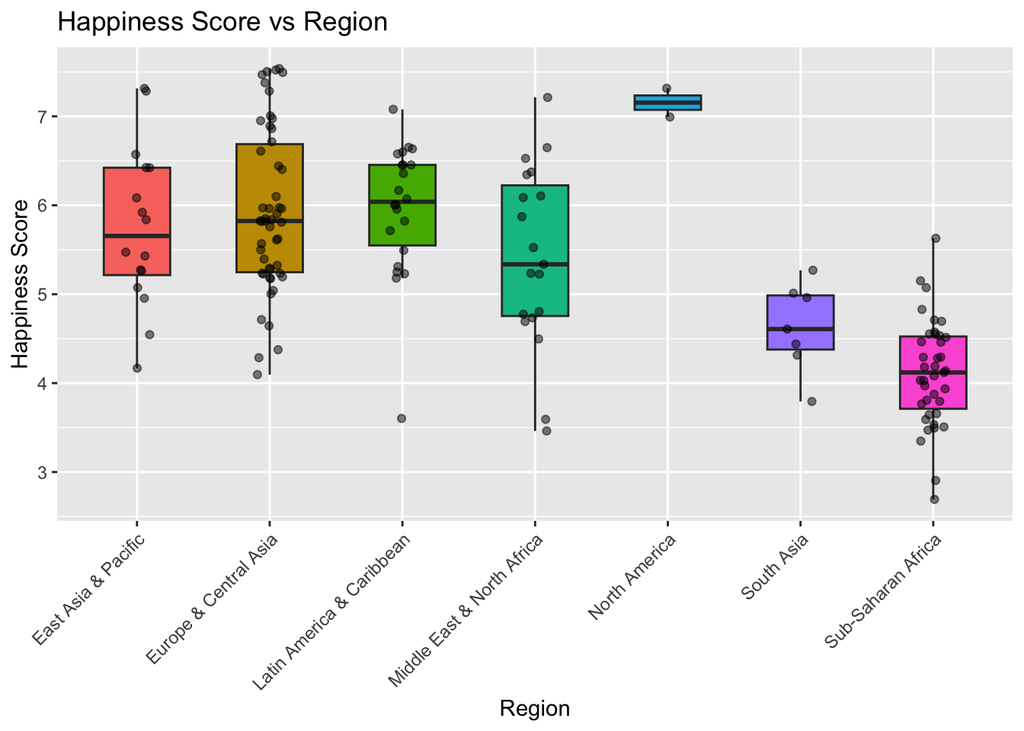

```r
#Happiness Score v Region boxplot
ggplot(newhappiness, aes(x=Region,y=Happiness.Score, fill=Region)) +
  geom_boxplot(width=0.5, length=1,outlier.shape = NA) +
  geom_jitter(width = 0.1, alpha=0.5) +
  labs(title="Happiness Score vs Region", y = "Happiness Score", x="Region") +
  theme(legend.position = 'none') +
  theme(axis.text.x = element_text(angle = 45, vjust = 1, hjust = 1))
```

```r
#creating subsets for each region
EUCAShappiness<- subset(newhappiness, Region=="Europe & Central Asia")
NAhappiness<-subset(newhappiness, Region=="North America")
EASPhappiness<-subset(newhappiness, Region=="East Asia & Pacific")
LAChappiness<-subset(newhappiness, Region=="Latin America & Caribbean")
MENAhappiness<-subset(newhappiness, Region=="Middle East & North Africa")
SAhappiness<-subset(newhappiness, Region=="South Asia")
SSAhappiness<-subset(newhappiness, Region=="Sub-Saharan Africa")
```

This boxplot gives us information on the distribution of `Happiness.Score`. The region with the highest reported `Happiness.Score` was North America, with a mean of 7.1545, and the lowest region was Sub-Saharan Africa, with a mean of 4.1119487. I created a table containing the means of each region to contextualize these differences better. Using the geom_jitter function, the boxplot gives us additional information about the distribution and size of `Happiness.Score` data per region. For example, North America and South Asia have very small samples compared to the other areas. North America only contained two data points, and South Asia included seven.

|  | Mean Happiness Score |
| --- | --- |
| East Asia & Pacific | 5.7523125 |
| Europe & Central Asia | 5.93278 |
| Latin America & Caribbean | 5.9578182 |
| Middle East & North Africa | 5.4237368 |
| North America | 7.1545 |
| South Asia | 4.6284286 |
| Sub-Saharan Africa | 4.1119487 |

## 2.2 Addressing our Smart Question

Now that I have taken a brief look at the dataset, I can look toward answering the SMART question: “based on data collected in the 2017 World Happiness Report, which features are most impactful in determining a happiness score, and how much do these correlations differ across regions?”

### 2.2.1 Correlation Matrices for Individual Regions

#### 2.2.1.1 Europe & Central Asia

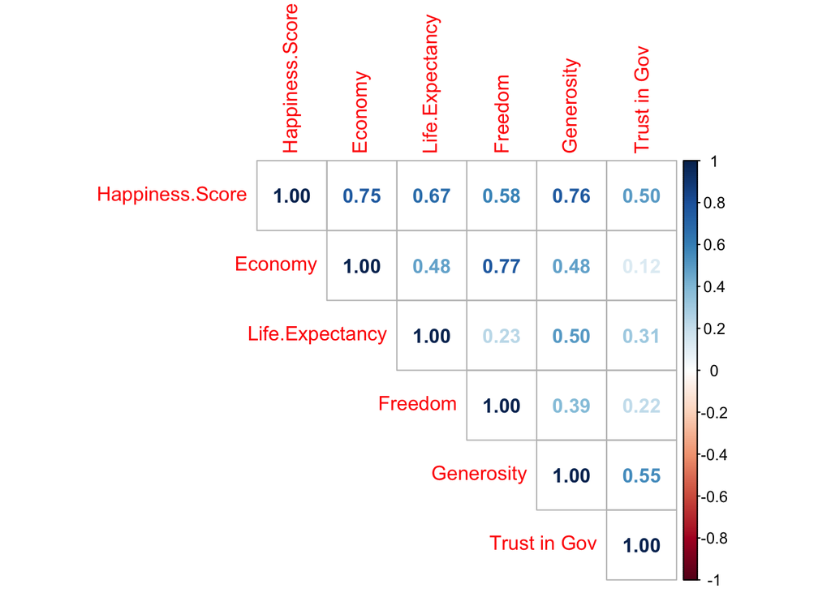

```r
#corrplot for each region
EUCAScorplot<-cor(EUCAShappiness[3:8])
corrplot(EUCAScorplot, type="upper",  method = 'number')
```

In Europe and Central Asia correlation matrix, `Happiness.Score` was strongly correlated with `Economy` and `Generosity` scores, while the remaining scores are were moderately correlated with `Happiness.Score`.

#### 2.2.1.2 North America

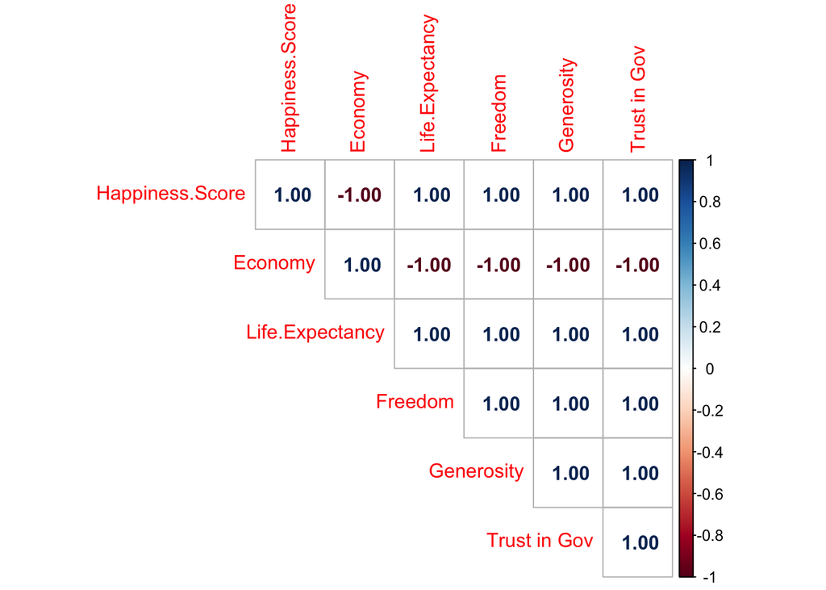

```r
NAcorplot<-cor(NAhappiness[3:8])
corrplot(NAcorplot, type="upper", method = 'number')
```

The numbers produced by this correlation matrix are unproductive as the sample size was too small due to containing only two countries, so the correlation between particular variables and `Happiness.Score` cannot be seen.

#### 2.2.1.3 East Asia & Pacific

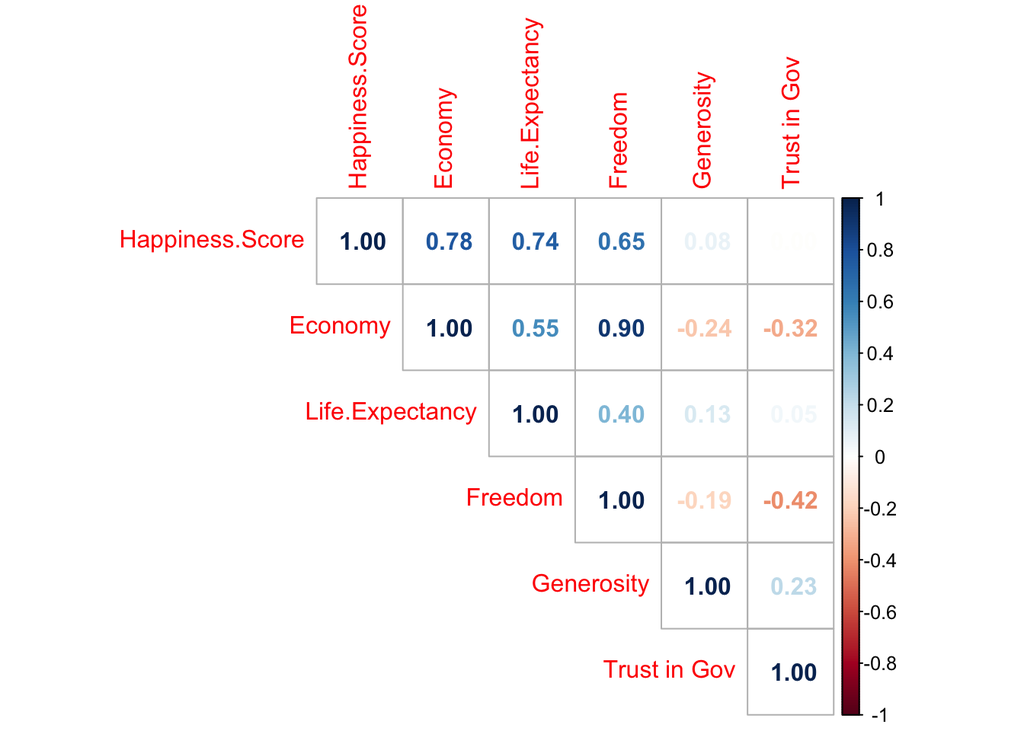

```r
EASPcorplot<-cor(EASPhappiness[3:8])
corrplot(EASPcorplot, type="upper", method = 'number')
```

In East Asia & the Pacific correlation matrix, `Happiness.Score` was correlated most with `Economy` and `Life.Expectancy`. `Happiness.Score` was moderately correlated with `Freedom` scores and was least correlated with `Trust in Gov` and `Generosity` scores.

#### 2.2.1.4 Latin America & Caribbean

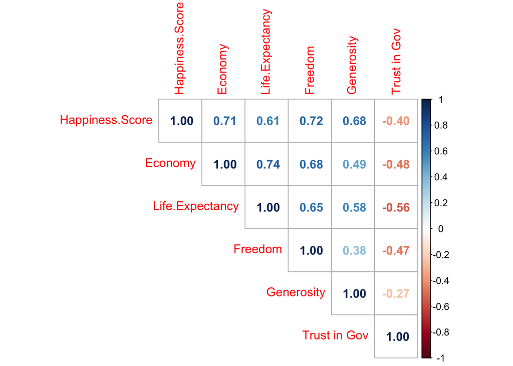

```r
LACcorplot<-cor(LAChappiness[3:8])
corrplot(LACcorplot, type="upper", method = 'number')
```

In Latin America and the Caribbean correlation matrix, `Happiness.Score` was strongly correlated with `Economy` and `Freedom` scores. `Generosity` and `Life.Expectancy` are moderately correlated with `Happiness.Score`.

#### 2.2.1.5 Middle East & North Africa

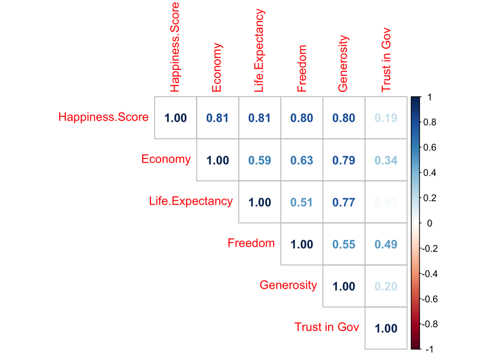

```r
MENAcorplot<-cor(MENAhappiness[3:8])
corrplot(MENAcorplot, type="upper", method = 'number')
```

In the Middle East and North Africa correlation matrix, `Happiness.Score` was strongly correlated with the `Economy`, `Life.Expectancy`, and `Generosity` scores. These scores were all evenly correlated with `Happiness.Score`, with a correlation ranging from .81 to .8. `Happiness.Score` was least correlated with `Trust in Gov`scores.

#### 2.2.1.6 South Asia

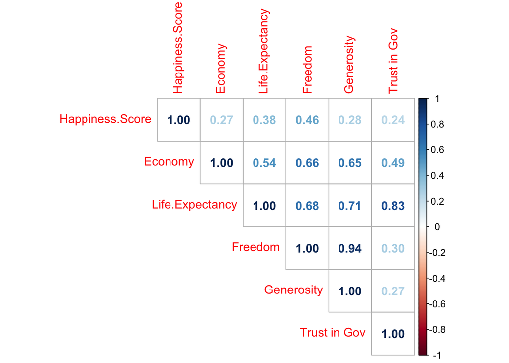

```r
SAcorplot<-cor(SAhappiness[3:8])
corrplot(SAcorplot, type="upper", method = 'number')
```

South Asia had the same issue as North America as they both lacked sample size, so I do not feel confident in making conclusions about the specific correlations.

#### 2.2.1.7 Sub-Saharan Africa

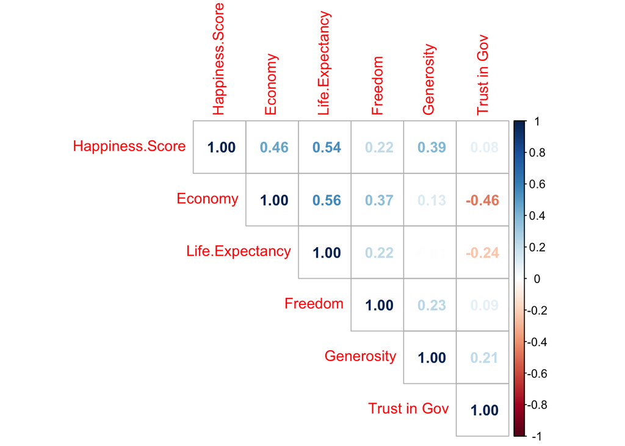

```r
SSAcorplot<-cor(SSAhappiness[3:8])
corrplot(SSAcorplot, type="upper", method = 'number')
```

There were no strong correlations for `Happiness.Score` in Sub-Saharan Africa. However, `Economy` and `Life.Expectancy` scores were moderately correlated with `Happiness.Score`.

### 2.2.2 Correlation Matrices Analysis

There was variation among the correlation of specific scores on `Happiness.Score` that depended upon the region. I also saw noticeable trends when we looked at each matrix. First, the most commonly strongly correlated variable to `Happiness.Score` was `Economy`. However, other variables might be strongly correlated depending on the region. I created a table of the strongly and moderately correlated variables to `Happiness.Score` per region.

|  | Strongly Correlated | Moderately Correlated |
| --- | --- | --- |
| East Asia & Pacific | Economy and Life Expectancy | Freedom |
| Europe & Central Asia | Economy and Generosity | Trust in Gov, Freedom, & Life Expectancy |
| Latin America & Caribbean | Economy and Freedom | Trust in Gov, Generosity, & Life Expectancy |
| Middle East & North Africa | Economy, Life Expectancy, Freedom, & Generosity | None |
| North America | N/A | N/A |
| South Asia | N/A | N/A |
| Sub-Saharan Africa | None | Economy, Life Expectancy, & Generosity |

This table shows that `Economy`, `Freedom`, and `Life.Expectancy` is the most commonly strongly or moderately correlated variables. This statement aligns with the initial correlation plot I looked at.

#### 2.2.2.1 Scatter Plots

Now that I found the differences between each region and which variables are most correlated with `Happiness.Score` per region, I looked at the linear relationship between `Happiness.Score`and the variables I found to be most correlated.

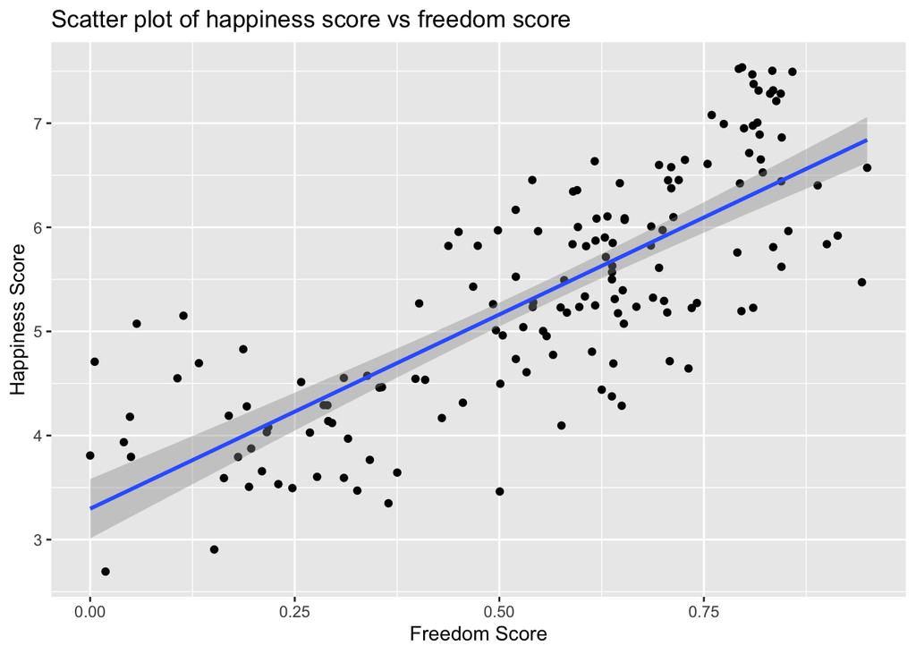

```r
plit<- ggplot(newhappiness, aes(x=Freedom, y=Happiness.Score))+
  geom_point()+
  geom_smooth(method = 'lm')+
  labs(title="Scatter plot of happiness score vs freedom score", x = "Freedom Score", y = "Happiness Score")
suppressMessages(print(plit))
```

I first examined the scatter plot between `Freedom` scores and `Happiness.Score`. There appeared to be a positive relationship between the two variables.

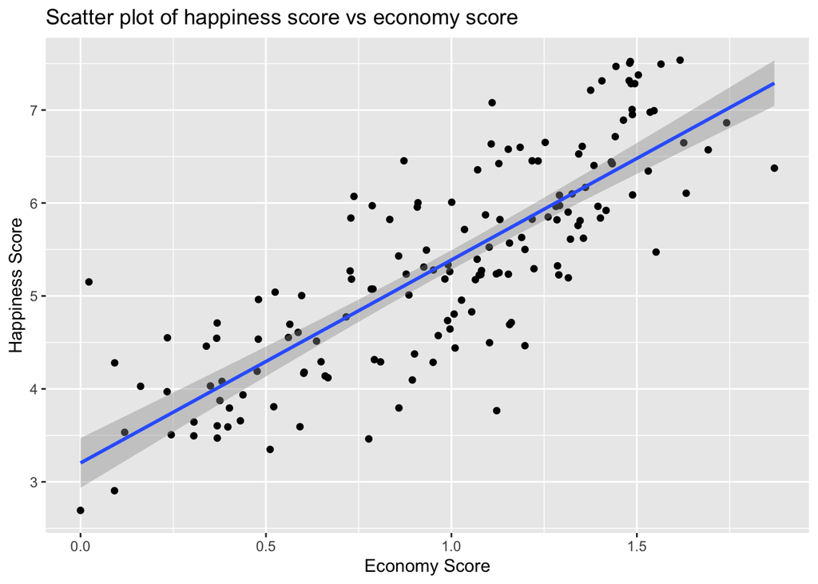

```r
plot2<-ggplot(newhappiness, aes(x=Economy, y=Happiness.Score))+
  geom_point()+
  geom_smooth(method = 'lm')+
  labs(title="Scatter plot of happiness score vs economy score", x = "Economy Score", y = "Happiness Score")
suppressMessages(print(plot2))
```

The relationship between `Happiness.Score` and `Economy` was also positive. This relationship looked similarly positively correlated to `Freedom` scores. My correlation matrix analysis would assert this because it showed that `Happiness.Score` correlated most with `Economy` and `Freedom`.

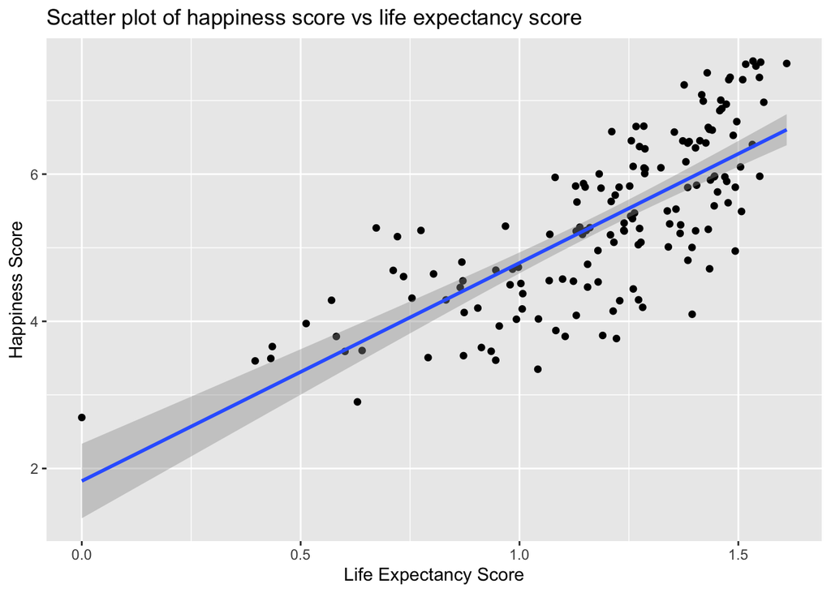

```r
plot<-ggplot(newhappiness, aes(x=Life.Expectancy, y=Happiness.Score))+
  geom_point()+
  geom_smooth(method = 'lm')+
  labs(title="Scatter plot of happiness score vs life expectancy score", x = "Life Expectancy Score", y = "Happiness Score")
suppressMessages(print(plot))
```

### 2.2.3 Feature Importance Test

```r
newhappiness$economy_z<-scale(newhappiness$Economy)
newhappiness$freedom_z<-scale(newhappiness$Freedom)
newhappiness$life.expectancy_z<-(newhappiness$Life.Expectancy)
```

#### 2.2.3.1 Regression Results

```r
#linear regression modeling
Economylifeexpectancyfreedomonscore <- lm(Happiness.Score ~ economy_z+freedom_z+life.expectancy_z , data = newhappiness)
Economylifeexpectancyfreedomonscoresum <-summary(Economylifeexpectancyfreedomonscore, title = "Summary of the linear model for feature importance")
```

```r
Economylifeexpectancyfreedomonscoresum
```

```
##
## Call:
## lm(formula = Happiness.Score ~ economy_z + freedom_z + life.expectancy_z,
##     data = newhappiness)
##
## Residuals:
##      Min       1Q   Median       3Q      Max
## -1.49825 -0.35335 -0.04934  0.38729  1.89215
##
## Coefficients:
##                   Estimate Std. Error t value Pr(>|t|)
## (Intercept)        3.71633    0.26390  14.082  < 2e-16 ***
## economy_z          0.36362    0.09237   3.936 0.000126 ***
## freedom_z          0.33581    0.08474   3.963 0.000114 ***
## life.expectancy_z  1.37748    0.21868   6.299 3.11e-09 ***
## ---
## Signif. codes:  0 '***' 0.001 '**' 0.01 '*' 0.05 '.' 0.1 ' ' 1
##
## Residual standard error: 0.5636 on 151 degrees of freedom
## Multiple R-squared:  0.7566, Adjusted R-squared:  0.7517
## F-statistic: 156.4 on 3 and 151 DF,  p-value: < 2.2e-16
```

```r
vif(Economylifeexpectancyfreedomonscore)
```

```
##         economy_z         freedom_z life.expectancy_z
##          4.136195          3.480671          1.912949
```

I also looked at the VIF of the variables within the model to ensure that multi-collinearity is not a concern for my data. With VIF values less than 5, I can conclude that there are not many collinearity concerns in the dataset.

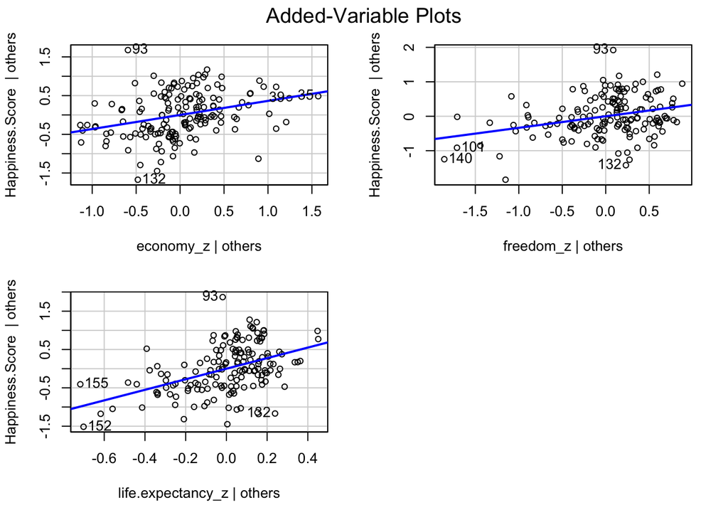

```r
#linear regression graph
avPlots(Economylifeexpectancyfreedomonscore)
```

# 3 Conclusion

## 3.1 Data Analysis

These results are supported by outside research on happiness. In an article on the 2021 World Happiness Report results, Lyndsey Matthews identified the variables life expectancy and economy “to be highly predictive of happiness” (Matthews, 2022). She also found that the happiest countries always have strong scores in these variables and high levels of freedom. In addition, another report on the effect of government policy on happiness from the London School of Economics reaffirmed Matthews’s statement. It claimed that a country’s happiness is most affected by “their incomes and employment” (Stewart, 2020). This means that a country with low income and employment levels will be unhappy, and this is supported in my analysis as I found `Economy` among the three most important variables. Thus, these outside sources supported the results of my data analysis.

## 3.2 Social Good

# 4 Sources

United Nations Sustainable Development Solutions Network. (n.d.). World happiness [Data set]. Kaggle. Retrieved from https://www.kaggle.com/datasets/unsdsn/world-happiness?select=2017.csv

Sustainable Development Solutions Network. (2017). World Happiness Report [Data set]. Retrieved from https://worldhappiness.report/ed/2017/

Lee, L. O., James, P., Zevon, E. S., Kim, E. S., Trudel-Fitzgerald, C., Spiro, A., 3rd, Grodstein, F., & Kubzansky, L. D. (2019). Optimism is associated with exceptional longevity in 2 epidemiologic cohorts of men and women. Proceedings of the National Academy of Sciences of the United States of America, 116(37), 18357–18362. https://doi.org/10.1073/pnas.1900712116

Matthews, L. (2022, August 25). “The world’s happiest country is all about reading, coffee, and Saunas.” AFAR Media. Retrieved December 12, 2022, from https://www.afar.com/magazine/the-worlds-happiest-country-is-all-about-reading-coffee-and-saunas.

Stewart, K. (2020, March 17). We Can Increase Happiness Through Public Policy (And In Our Jobs and Private Lives Too) [Blog post]. Retrieved from https://blogs.lse.ac.uk/businessreview/2020/03/17/we-can-increase-happiness-through-public-policy-and-in-ou r-jobs-and-private-lives-too/